# Analysis of Inpatient Admissions

Galih Fitriatmo

2025-01-31

## Load Library

```r
library(stats)
library(tidyverse)
library(tseries)
library(forecast)
library(dplyr)
library(readxl)
library(MASS)
library(lmtest)
library(nortest)
library(readr)
```

## Load Data

```r
data <- read_csv("Data/data_pengunjung.csv", col_types = cols(
  Tanggal = col_date(format = "%d/%m/%Y"),
  Hari = col_character(),
  Value = col_double(),
  Subset = col_character()
))
print(data)
```

```
## # A tibble: 672 × 4
##    Tanggal    Hari  Value Subset
##    <date>     <chr> <dbl> <chr>
##  1 2022-03-07 Mon      48 Train
##  2 2022-03-08 Tue      96 Train
##  3 2022-03-09 Wed      84 Train
##  4 2022-03-10 Thu     126 Train
##  5 2022-03-11 Fri     102 Train
##  6 2022-03-12 Sat      84 Train
##  7 2022-03-13 Sun     108 Train
##  8 2022-03-14 Mon     126 Train
##  9 2022-03-15 Tue      90 Train
## 10 2022-03-16 Wed     114 Train
## # ℹ 662 more rows
```

## Split Data

```r
data_train <- data %>% filter(Subset == "Train")
data_fix <- ts(data_train$Value, frequency = 7, start = c(1, 1))
```

## Descriptive Statistics

```r
summary_stats <- data_train %>%
  summarize(
    Mean = mean(Value, na.rm = TRUE),
    Median = median(Value, na.rm = TRUE),
    Min = min(Value, na.rm = TRUE),
    Max = max(Value, na.rm = TRUE)
  )
summary_stats
```

```
## # A tibble: 1 × 4
##    Mean Median   Min   Max
##   <dbl>  <dbl> <dbl> <dbl>
## 1  123.    120    12   270
```

Based on the output, the average number of inpatient admissions at the hospital is 122.6645963 patients. The lowest number of admissions occurred on 2023-02-25 with 12 patients, while the highest occurred on 2023-05-03 with 270 patients.

## Daily Patient arrivals

```r
summary_by_day <- data_train %>%
  group_by(Hari) %>%
  summarize(Mean = mean(Value, na.rm = TRUE)) %>%
  arrange(factor(Hari, levels = c("Mon", "Tue", "Wed", "Thu", "Fri", "Sat", "Sun")))
summary_by_day
```

```
## # A tibble: 7 × 2
##   Hari   Mean
##   <chr> <dbl>
## 1 Mon   121.
## 2 Tue   140.
## 3 Wed   144.
## 4 Thu   132.
## 5 Fri   131.
## 6 Sat   104.
## 7 Sun    87.6
```

Based on the output, the highest average number of patient arrivals occurred on Wed and the lowest occurred on Sun.

## Time Series Visualization

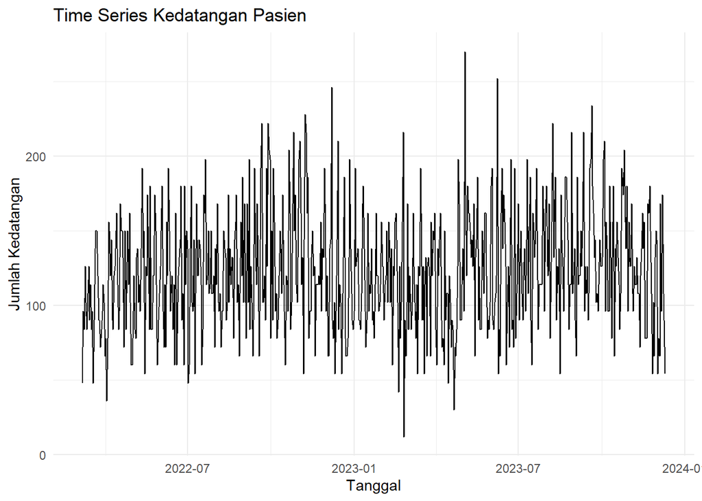

```r
ggplot(data_train, aes(x = Tanggal, y = Value)) +
  geom_line() +
  labs(title = "Time Series Kedatangan Pasien", x = "Tanggal", y = "Jumlah Kedatangan") +
  theme_minimal()
```

From the plot above, the number of inpatient admissions fluctuates significantly, but no clear trend is observed. It can also be seen that inpatient visits tend to follow a weekly cycle, rising and falling every seven days. The increase usually starts on Monday, peaks on Wednesday, and then begins to decline on Saturday. The lowest number of inpatient admissions typically occurs on Sunday, as some clinics are closed, preventing patient transfers from outpatient to inpatient care. This indicates a seasonal pattern in the number of inpatient admissions.

## Stationarity Check

### Stationarity Test on Variance

The stationarity check on variance is performed using Box-Cox transformation. The results are as follows

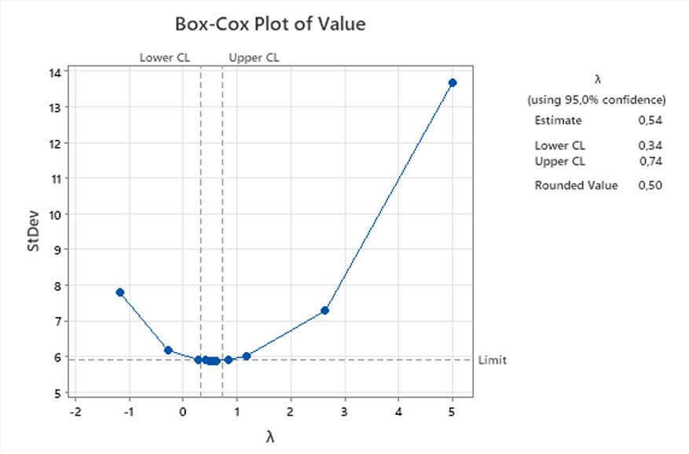

Based on the output, the rounded value obtained is 0.5, indicating the need for transformation. The transformation is performed using the formula 𝑍𝑡 = √𝑌𝑡, and the results are displayed in the output below.

```r
lambda <- BoxCox.lambda(data_fix)
data_fix_transformed <- BoxCox(data_fix, lambda)
```

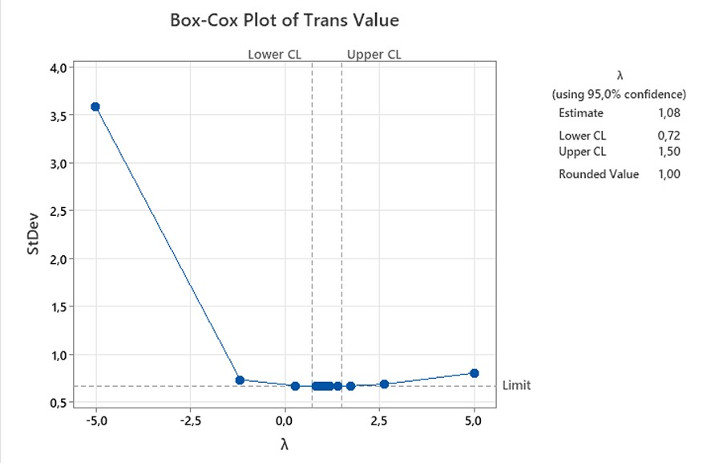

Based on the output, the rounded value obtained is 1, indicating that the transformed data is now stationary in variance. The next step is to check for stationarity in the mean.

### Stationarity Test on Mean

The stationarity check on the mean can be performed using the ACF and PACF plots of the transformed data.

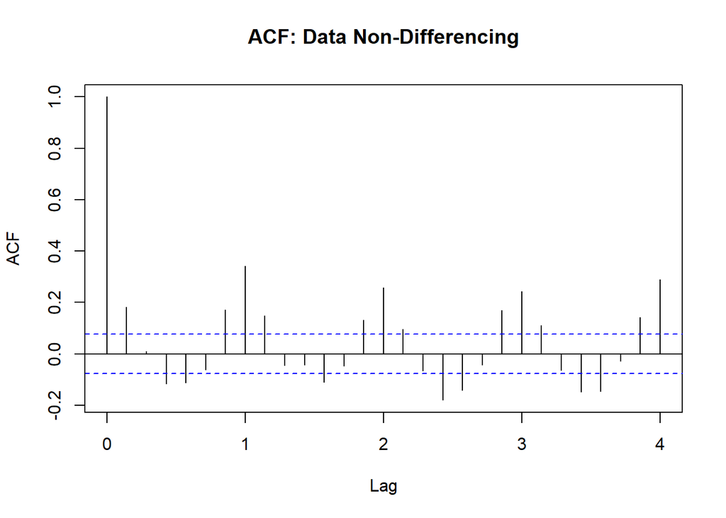

```r
acf(data_fix_transformed, main = "ACF: Data Non-Differencing")
```

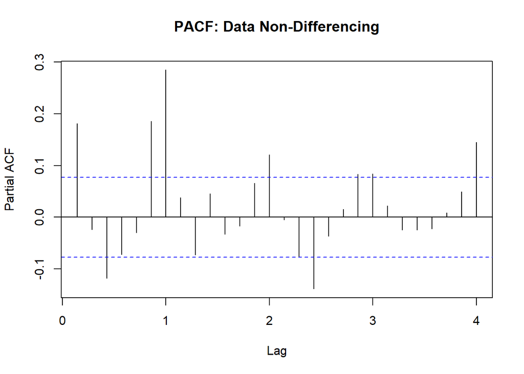

```r
pacf(data_fix_transformed, main = "PACF: Data Non-Differencing")
```

#### Differencing for Stationarity

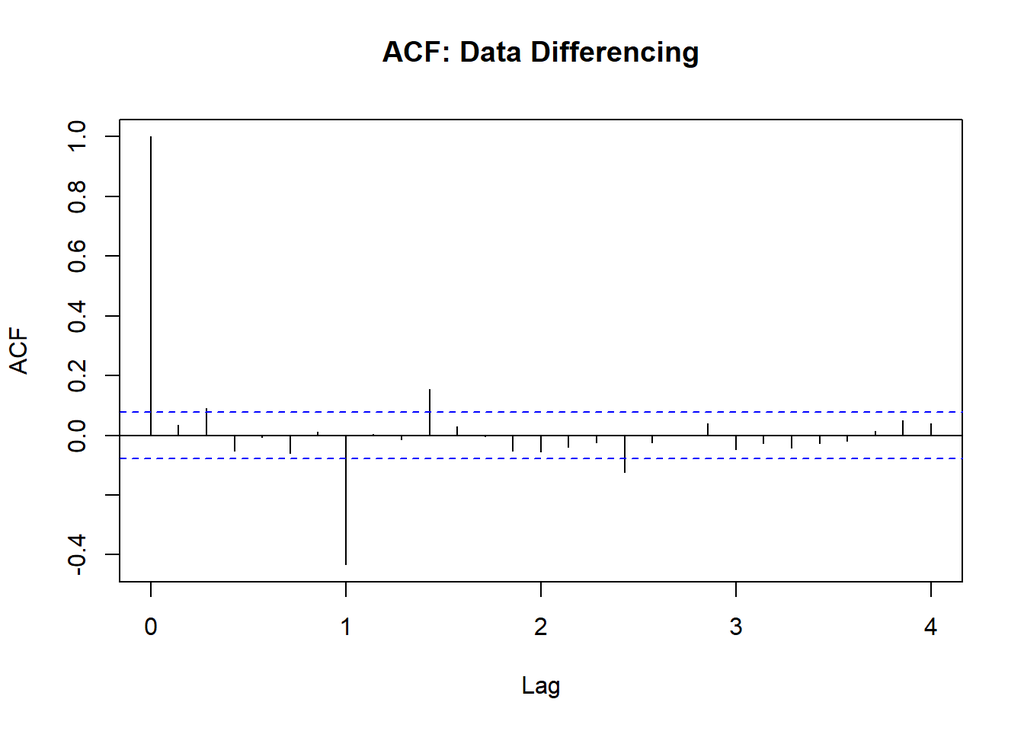

```r
data_diff_fix <- diff(data_fix_transformed, lag = 7, differences = 1)
acf(data_diff_fix, main = "ACF: Data Differencing")
```

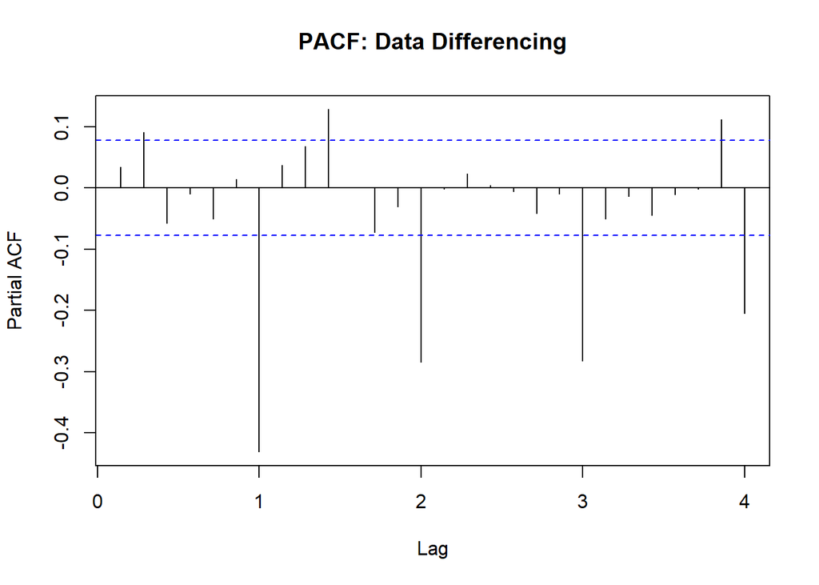

```r
pacf(data_diff_fix, main = "PACF: Data Differencing")
```

Based on the output, it can be seen that the ACF pattern no longer slowly dies down, indicating that the differenced data is now stationary in terms of the mean. Data that is stationary in both variance and mean can be modeled based on the ACF and PACF plots. The output sequentially presents the ACF and PACF plots of the stationary data. Based on the ACF plot, there is a spike at lag 2 followed by a cut-off after lag 2. Additionally, for the seasonal component, there is a spike at lag 7 with a cut-off after lag 7. Meanwhile, the PACF plot shows a gradually decreasing pattern at seasonal levels, specifically at lags 7, 14, 21, and 28. Based on the plot analysis, the suspected SARIMA models are SARIMA(0,0,2)(0,1,1)7, SARIMA(0,0,[2])(0,1,1)7, and SARIMA(0,0,2)(1,1,1)7.

## SARIMA Modeling

```r
model_SARIMA1 <- Arima(data_fix_transformed, order = c(0,0,2), seasonal = list(order = c(0,1,1), period = 7))

model_SARIMA2 <- Arima(data_fix_transformed, order = c(0,0,2), seasonal = list(order = c(1,1,1), period = 7))

model_SARIMA3 <- Arima(data_fix_transformed, order = c(0,0,7), seasonal = list(order = c(0,1,1), period = 7), fixed = c(0, NA, rep(0, 4), 0, NA))
```

## Testing SARIMA Model Parameter

```r
coeftest(model_SARIMA1)
```

```
##
## z test of coefficients:
##
##       Estimate Std. Error  z value Pr(>|z|)
## ma1   0.074195   0.039905   1.8593  0.06298 .
## ma2   0.085187   0.038693   2.2016  0.02769 *
## sma1 -0.905111   0.030140 -30.0306  < 2e-16 ***
## ---
## Signif. codes:  0 '***' 0.001 '**' 0.01 '*' 0.05 '.' 0.1 ' ' 1
```

```r
coeftest(model_SARIMA2)
```

```
##
## z test of coefficients:
##
##       Estimate Std. Error  z value  Pr(>|z|)
## ma1   0.072218   0.039773   1.8158  0.069408 .
## ma2   0.094769   0.038979   2.4312  0.015047 *
## sar1  0.128411   0.046157   2.7821  0.005401 **
## sma1 -0.958141   0.027136 -35.3093 < 2.2e-16 ***
## ---
## Signif. codes:  0 '***' 0.001 '**' 0.01 '*' 0.05 '.' 0.1 ' ' 1
```

```r
coeftest(model_SARIMA3)
```

```
##
## z test of coefficients:
##
##       Estimate Std. Error  z value Pr(>|z|)
## ma2   0.088870   0.039193   2.2675  0.02336 *
## sma1 -0.899284   0.030163 -29.8143  < 2e-16 ***
## ---
## Signif. codes:  0 '***' 0.001 '**' 0.01 '*' 0.05 '.' 0.1 ' ' 1
```

## Diagnostic Check

The diagnostic check is conducted to assess whether the errors in the data are random or independent and follow a normal distribution. The randomness of errors is examined using the Ljung-Box test.

```r
lags <- c(7,14,21,28,35)
diagnostic_tests <- function(model, lags) {
  ljung_box_results <- lapply(lags, function(lag) {
    test <- Box.test(model$residuals, type = "Ljung-Box", lag = lag)
    data.frame(Lag = lag, Statistic = test$statistic, p_value = test$p.value)
  })

  lillie_test <- lillie.test(model$residuals)
  coef_test <- coeftest(model)
  ljung_box_df <- do.call(rbind, ljung_box_results)
  lillie_test_df <- data.frame(Test = "Lilliefors", Statistic = lillie_test$statistic, p_value = lillie_test$p.value)

  list(Coefficient_Test = coef_test, Ljung_Box = ljung_box_df, Lilliefors = lillie_test_df)
}
```

```r
result_SARIMA1 <- diagnostic_tests(model_SARIMA1, lags)
print(result_SARIMA1)
```

```
## $Coefficient_Test
##
## z test of coefficients:
##
##       Estimate Std. Error  z value Pr(>|z|)
## ma1   0.074195   0.039905   1.8593  0.06298 .
## ma2   0.085187   0.038693   2.2016  0.02769 *
## sma1 -0.905111   0.030140 -30.0306  < 2e-16 ***
## ---
## Signif. codes:  0 '***' 0.001 '**' 0.01 '*' 0.05 '.' 0.1 ' ' 1
##
##
## $Ljung_Box
##            Lag Statistic   p_value
## X-squared    7  7.552041 0.3737444
## X-squared1  14 17.867927 0.2128625
## X-squared2  21 28.284359 0.1322693
## X-squared3  28 32.783180 0.2438202
## X-squared4  35 42.826175 0.1705545
##
## $Lilliefors
##         Test  Statistic   p_value
## D Lilliefors 0.01828572 0.8666523
```

```r
result_SARIMA2 <- diagnostic_tests(model_SARIMA2, lags)
print(result_SARIMA2)
```

```
## $Coefficient_Test
##
## z test of coefficients:
##
##       Estimate Std. Error  z value  Pr(>|z|)
## ma1   0.072218   0.039773   1.8158  0.069408 .
## ma2   0.094769   0.038979   2.4312  0.015047 *
## sar1  0.128411   0.046157   2.7821  0.005401 **
## sma1 -0.958141   0.027136 -35.3093 < 2.2e-16 ***
## ---
## Signif. codes:  0 '***' 0.001 '**' 0.01 '*' 0.05 '.' 0.1 ' ' 1
##
##
## $Ljung_Box
##            Lag Statistic   p_value
## X-squared    7  2.970168 0.8877481
## X-squared1  14 13.568581 0.4823211
## X-squared2  21 22.346464 0.3797859
## X-squared3  28 27.351805 0.4991580
## X-squared4  35 39.201713 0.2869120
##
## $Lilliefors
##         Test  Statistic   p_value
## D Lilliefors 0.02342219 0.5309554
```

```r
result_SARIMA3 <- diagnostic_tests(model_SARIMA3, lags)
print(result_SARIMA3)
```

```
## $Coefficient_Test
##
## z test of coefficients:
##
##       Estimate Std. Error  z value Pr(>|z|)
## ma2   0.088870   0.039193   2.2675  0.02336 *
## sma1 -0.899284   0.030163 -29.8143  < 2e-16 ***
## ---
## Signif. codes:  0 '***' 0.001 '**' 0.01 '*' 0.05 '.' 0.1 ' ' 1
##
##
## $Ljung_Box
##            Lag Statistic    p_value
## X-squared    7  10.36175 0.16898339
## X-squared1  14  20.96717 0.10247683
## X-squared2  21  32.13707 0.05670544
## X-squared3  28  37.45709 0.10911813
## X-squared4  35  47.35736 0.07931509
##
## $Lilliefors
##         Test  Statistic  p_value
## D Lilliefors 0.02600699 0.361853
```

Since both models meet the white noise assumption and their residuals are normally distributed, they can be used for forecasting.

## Model Evaluation with Test Data

### Data Preparation

After going through various stages in the SARIMA method, several suitable models have been identified for forecasting. Next, these models are evaluated based on RMSE and MAPE, with the model having the smallest error selected for forecasting. The evaluation is conducted using test data, covering inpatient admission records from **December 11, 2023, to January 7, 2024**, consisting of **28 observations**. The test data is much smaller than the train data because SARIMA is not well-suited for long-term forecasting. The test data is not included in the training data.

```r
data_test <- data[data$Subset == "Test",]
test_data <- data_test[, c("Tanggal", "Value")]
test_data_ts <- ts(test_data$Value, frequency = 7, start = c(1, 1))
test_data_transformed <- BoxCox(test_data_ts, lambda)
```

### Performing Forecasting for All Models That Meet Assumptions

```r
forecasts_test_SARIMA1 <- forecast(model_SARIMA1, h = length(test_data_transformed))
forecast_values_test_SARIMA1_original_scale <- InvBoxCox(forecasts_test_SARIMA1$mean, lambda)

forecasts_test_SARIMA2 <- forecast(model_SARIMA2, h = length(test_data_transformed))
forecast_values_test_SARIMA2_original_scale <- InvBoxCox(forecasts_test_SARIMA2$mean, lambda)
```

The forecasting results are shown in the output below.

```r
results <- data.frame(
  Date = data_test$Tanggal,
  Day = data_test$Hari,
  Actual_Value = data_test$Value,
  Predicted_Value_SARIMA1 = forecast_values_test_SARIMA1_original_scale,
  Predicted_Value_SARIMA2 = forecast_values_test_SARIMA2_original_scale
)
results
```

```
##          Date    Day Actual_Value Predicted_Value_SARIMA1
## 1  2023-12-11  Senin          138               113.18169
## 2  2023-12-12 Selasa          156               139.37966
## 3  2023-12-13   Rabu          138               135.25537
## 4  2023-12-14  Kamis          144               141.51757
## 5  2023-12-15  Jumat          108               139.70984
## 6  2023-12-16  Sabtu           90               103.09303
## 7  2023-12-17 Minggu           60                88.11334
## 8  2023-12-18  Senin           96               117.40114
## 9  2023-12-19 Selasa          168               143.16959
## 10 2023-12-20   Rabu          174               135.25537
## 11 2023-12-21  Kamis          216               141.51757
## 12 2023-12-22  Jumat          132               139.70984
## 13 2023-12-23  Sabtu           96               103.09303
## 14 2023-12-24 Minggu           66                88.11334
```

[output cut: 43 more lines]

### Model Evaluation

```r
rmse <- function(actual, predicted) {
  sqrt(mean((actual - predicted)^2))
}

mape <- function(actual, predicted) {
  mean(abs((actual - predicted) / actual)) * 100
}

rmse_SARIMA1 <- rmse(results$Actual_Value, results$Predicted_Value_SARIMA1)
mape_SARIMA1 <- mape(results$Actual_Value, results$Predicted_Value_SARIMA1)

rmse_SARIMA2 <- rmse(results$Actual_Value, results$Predicted_Value_SARIMA2)
mape_SARIMA2 <- mape(results$Actual_Value, results$Predicted_Value_SARIMA2)

summary_df <- data.frame(
  Model = c("SARIMA1", "SARIMA2"),
  RMSE = c(rmse_SARIMA1, rmse_SARIMA2),
  MAPE = c(mape_SARIMA1, mape_SARIMA2)
)
summary_df
```

```
##     Model     RMSE     MAPE
## 1 SARIMA1 28.57020 22.19397
## 2 SARIMA2 28.99893 22.02917
```

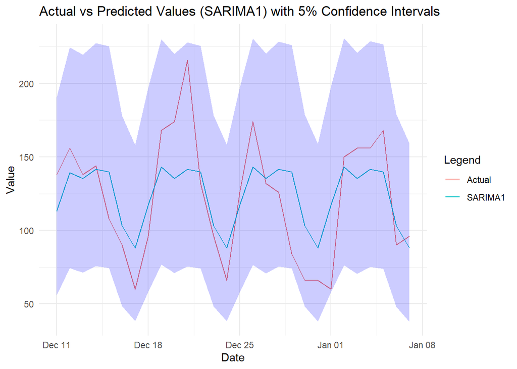

```r
ggplot(results, aes(x = Date)) +
  geom_line(aes(y = Actual_Value, color = "Actual")) +
  geom_line(aes(y = Predicted_Value_SARIMA1, color = "SARIMA1")) +
  geom_ribbon(aes(ymin = InvBoxCox(forecasts_test_SARIMA1$lower[, 2], lambda),
                  ymax = InvBoxCox(forecasts_test_SARIMA1$upper[, 2], lambda)),
              alpha = 0.2, fill = "blue") +
  labs(title = "Actual vs Predicted Values (SARIMA1) with 5% Confidence Intervals",
       x = "Date",
       y = "Value",
       color = "Legend") +
  theme_minimal()
```

The output shows the prediction results for the test data used. From the plot, it can be seen that the SARIMA(0,0,2)(0,1,1)₇ model performs well in forecasting. This is indicated by the predicted values being close to the actual values, and the confidence interval covering all actual values, demonstrating that the model’s uncertainty estimation is also reliable.